- [rcourse](http://nbviewer.ipython.org/github/pdparker/rcourse/tree/master) /
- Plots.ipynb /

# Plotting data in R

## Contents

1. [Basic exploration graphs](http://nbviewer.ipython.org/github/pdparker/rcourse/blob/master/Plots.ipynb#explore)
2. [Making graphs prettier](http://nbviewer.ipython.org/github/pdparker/rcourse/blob/master/Plots.ipynb#scatter)
3. [Plotting qualitative data](http://nbviewer.ipython.org/github/pdparker/rcourse/blob/master/Plots.ipynb#qual)
4. [Grammar of graphs](http://nbviewer.ipython.org/github/pdparker/rcourse/blob/master/Plots.ipynb#ggplots)

## Introduction

Graphics in R is far too large a topic to cover in a course like this. As such I have decided to keep it both very simple and very limited.

My statistical philosophy is that plotting of data should be central to all analysis from data screening, to exploration, to final product. In many ways visual display of information has the ability to better represent both trend and noise in a way that statistics cannot.

As I simple do not have the capacity to go through plotting in anywhere near sufficent detail, I detail the following links:

1. Grammar of graphs as instigated in R via [ggplots](http://www.amazon.com/dp/0387981403/ref=rdr_ext_sb_ti_hist_2)
2. Classic works by [Edward Tufte](http://www.amazon.com/Visual-Display-Quantitative-Information/dp/0961392142/ref=sr_1_1?ie=UTF8&qid=1425008534&sr=8-1&keywords=Edward+Tufte)
3. For beautiful graphs try [flowing data](http://flowingdata.com/)
4. For colour pallets [go here](http://www.colourlovers.com/palettes/search) or create your own [here](http://app.coolors.co/517561-629c7c-3b5d49-262f2a-324b3a] and use the hex values in R e.g., col = "#D7E8D5"
5. To see the possibilities go to [plotly](https://plot.ly/r/)
6. To just get stuff done try the [R cookbook](http://www.cookbook-r.com/Graphs/)
7. For inspiration on interactive graphs go to [gapminder](http://www.gapminder.org/) and produce the graphs in R with [googleVis](https://code.google.com/p/google-motion-charts-with-r/) or [shiny](http://shiny.rstudio.com/tutorial/lesson1/)
8. Real time animated graphs are also [possible](http://www.r-bloggers.com/syrian-refugee-informal-settlement-animation/)
9. Be a hipster and use Wes Anderson [colour pallets](https://github.com/karthik/wesanderson)
10. Animations in [R](https://trinker.github.io/qdap_examples/animation_dialogue/)

## Top Tips

1. Know the comands for plot, abline, line, hist, density, and curve to quickly generate graphs for exploration and production
2. pairs and corrplot will let you look at lots of pairwise relationships quickly
3. Start simply with default plot settings and slowly build up
4. For likert data use jitter to move points around a bit to better see relationships
5. For large data use alpha blending to make points semi transperent to better see where the density of points is (see alpha or rgb functions)
6. For big data use heat maps, [ggobi](http://www.ggobi.org/), [bigvis](https://github.com/hadley/bigvis/blob/master/README.md), or hexbin plots
7. Learn ggplots as this seems to be where everyone is heading
8. Many many functions have default plots so try throwing output from a function at plot(). For models this will often be plots of assumptions
9. Follow the general rule of avoiding chartjunk (Tufte, 1983 - Above all else show the data)
10. Know what devices are best to export to (you might want to export as an svg and do further work in illustrator or inkscape)
11. Know the big names and get their books, blogs, t-shirts (Edward Tufte, Stephen Few, Hadley Wickham).

[Top](http://nbviewer.ipython.org/github/pdparker/rcourse/blob/master/Plots.ipynb#top)

## Explore data with graphs

```python
#ignore python vodoo occuring in the cell
%load_ext rmagic
```

```
The rmagic extension is already loaded. To reload it, use:
  %reload_ext rmagic
```

```
re-encoding from UTF-8
```

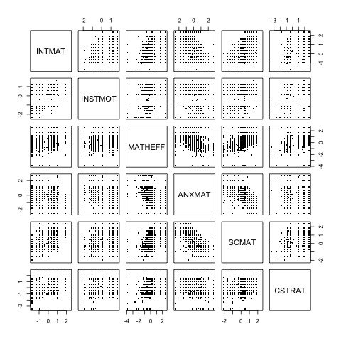

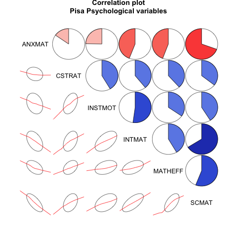

```python
%%R
library(ggplot2)
library(lattice)
library(corrgram)
library(vcd)
library(wesanderson)
library(foreign)
library(car)
setwd("/Users/phparker/Dropbox/Rcourse/data/")
pisa <- read.spss("PISA2003.sav", to.data.frame = TRUE, use.value.labels = FALSE)
names(pisa)
#Scatter plot matrix
pairs(pisa[,27:32], pch = ".", cex = 3)
#Correlation plot
corrgram(pisa[,27:32], lower.panel = panel.ellipse, upper.panel = panel.pie, order=TRUE,
		 main = "Correlation plot\nPisa Psychological variables")
```

[Top](http://nbviewer.ipython.org/github/pdparker/rcourse/blob/master/Plots.ipynb#top)

## Scatter plots, box plots, and Histograms

Here I give examples of moving from default graphs to prettier graphs.

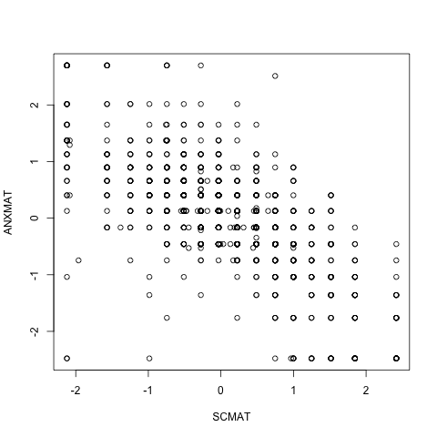

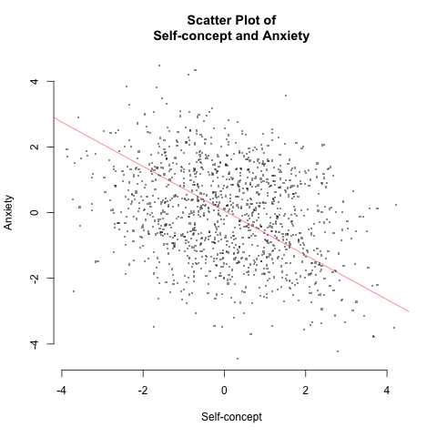

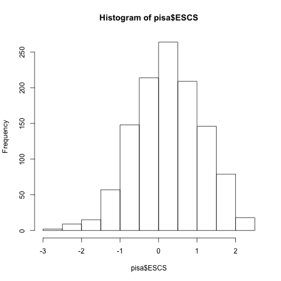

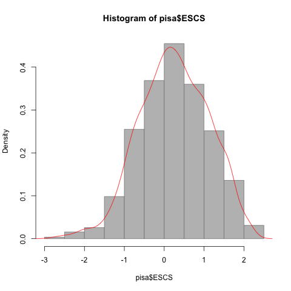

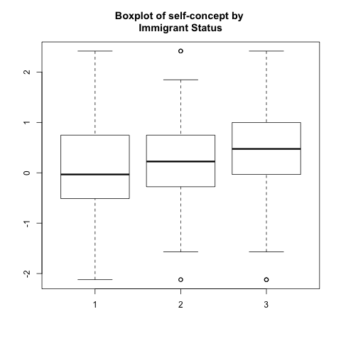

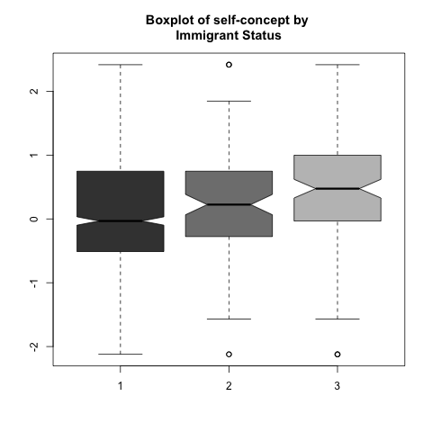

```python
%%R
#Scatter Plot - Ugly
with(pisa, plot(SCMAT, ANXMAT))

# Scatter Plot - Pretty
with(pisa, plot(jitter(SCMAT,amount = 2), jitter(ANXMAT,amount = 2), pch = ".", cex = 3, col = "#00000075",
				main = "Scatter Plot of\nSelf-concept and Anxiety", xlab = "Self-concept", ylab = "Anxiety",
				bty="n"))

#Lets add a regression line
abline(lm(pisa$ANXMAT ~ pisa$SCMAT), col = rgb(1,0,0,.6), cex = 2)

#Histogram - Ugly
hist(pisa$ESCS)
#Histogram - Pretty
hist(pisa$ESCS,freq = FALSE, col = "grey", border = "grey50")
lines(density(pisa$ESCS, na.rm=TRUE), col = "red")

#Bar plot - ugly
boxplot(SCMAT ~ IMMIG, data = pisa, main = "Boxplot of self-concept by \nImmigrant Status")
#Bar plot - pretty
boxplot(SCMAT ~ IMMIG, data = pisa, main = "Boxplot of self-concept by \nImmigrant Status",
		notch = TRUE, col = c("grey25", "grey50", "grey75") )
```

[Top](http://nbviewer.ipython.org/github/pdparker/rcourse/blob/master/Plots.ipynb#top)

## Mapping Qualitative Data

I don't really have a lot of experience with ploring qualitative data but when I have done stuff I have used either mosaic plots or foufold plots

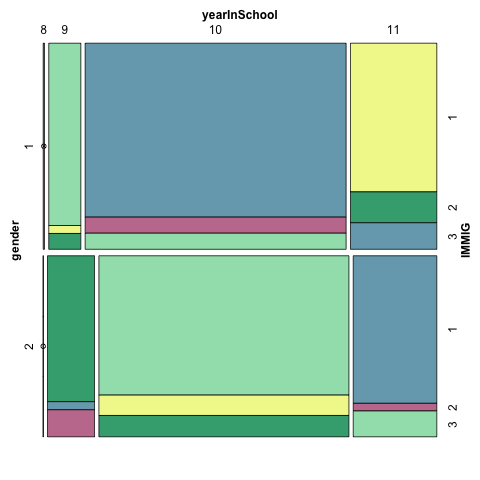

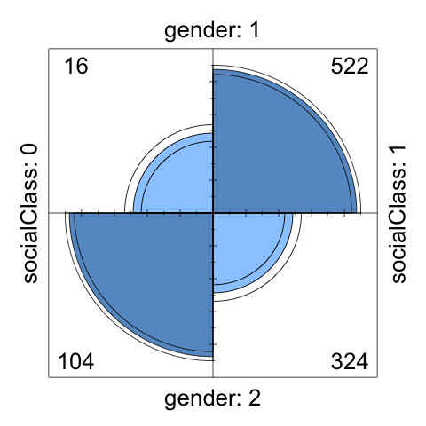

```python
%%R
#Categorical data plots - Mosaic
mosaic(IMMIG ~ yearInSchool | gender, data = pisa, highlighting_fill =
	   	c("#3FAA7F", "#77A8BA", "#C47D9D", "#A1E0B9", "#F1F799"))

# Fourfold plot on gender by self-report social class
    #Fourfold plots are for two by two contingency tables so we need to make a new variable
pisa$socialClass <- recode(pisa$SSECATEG, "c(1,2) = 1; c(3,4) = 0")
#Next we create a contingency table
myTable <- with(pisa, table(gender, socialClass))
#Then plot it
fourfoldplot(myTable, color = c("#99CCFF", "#6699CC"),
			 conf.level = 0.95,
			 std = c("margins", "ind.max", "all.max"),
			 margin = c(1, 2), space = 0.2, main = NULL,
			 mfrow = NULL, mfcol = NULL)
```

[Top](http://nbviewer.ipython.org/github/pdparker/rcourse/blob/master/Plots.ipynb#top)

## GGPLOTS

SPSS has, for sometime, tried to use a sort of grammar of graphs logic to their plots. However, SPSS does not really have this sort of flexibility required (at the very least I find it annoying). One of the main people in this framework, Hadley Wickham, however has made a grammar of graphs package for R called ggplots 2. I rarely use it as I now used to base graphics BUT ggplots are powerful and beautiful. Below I create a pretty scatter plot and full information bar chart (i.e. every data point is shown).

The idea behind ggplots is to build graphs in discreet stages or components seperated by '+'. ggplots also has a powerful faceting system in which multiple graphs are presented in rows and columns to provide a rich but readable picture of your data.

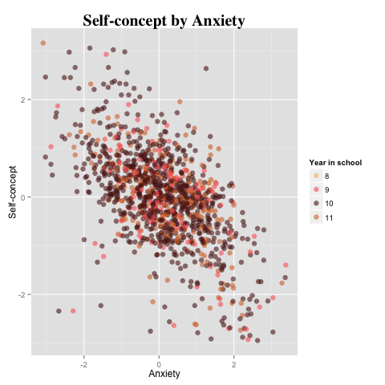

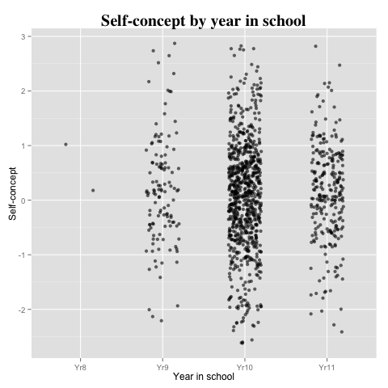

```python
%%R
#Scatter plot
library(ggplot2)
print(ggplot(pisa, aes(SCMAT, ANXMAT, color = as.factor(yearInSchool)) ) +
	geom_point(size = 3, position=position_jitter(width=1,height=.5), alpha = .6) +
	scale_color_manual(values = wes_palette("GrandBudapest")) +
	scale_x_continuous(name = "Anxiety") + scale_y_continuous(name = "Self-concept") +
	ggtitle("Self-concept by Anxiety") +
	theme(plot.title=element_text(family="Times", face="bold", size=20)) +
	guides(color=guide_legend(title="Year in school")) )
# Fancy bar plot
print(ggplot(pisa, aes(as.factor(yearInSchool),SCMAT) )+
	geom_point(position = position_jitter(width=.2,height=.5), alpha = 0.6) +
	scale_x_discrete(breaks= 8:11, labels=c("Yr8", "Yr9", "Yr10", "Yr11"), name = "Year in school") +
	scale_y_continuous(name="Self-concept") +
	ggtitle("Self-concept by year in school") +
	theme(plot.title=element_text(family="Times", face="bold", size=20)) )
```

[Top](http://nbviewer.ipython.org/github/pdparker/rcourse/blob/master/Plots.ipynb#top)

[Back to top](http://nbviewer.ipython.org/github/pdparker/rcourse/blob/master/Plots.ipynb#)